# The economic and social impact of child labor worldwide

Author

Aloïs Fallard

## **Introduction: The Persistent Challenge of Child Labor**

Child labor remains a major global concern. Despite progress made in recent decades, millions of children are still forced into work that robs them of their childhood, their potential, and their dignity, and that is detrimental to their physical and mental development.

*This report sheds light on the current state of child labor (ages 5-17)* around the world, exploring its links to macroeconomic factors such as Gross Domestic Product (GDP) and life expectancy, using UNICEF data.

### **1. A Global Overview of Child Labor**

To understand the scale of the problem, it is essential to map the distribution of child labor across the globe. The map below illustrates the percentage of children involved in economic activities and domestic work, based on the latest available data by country.

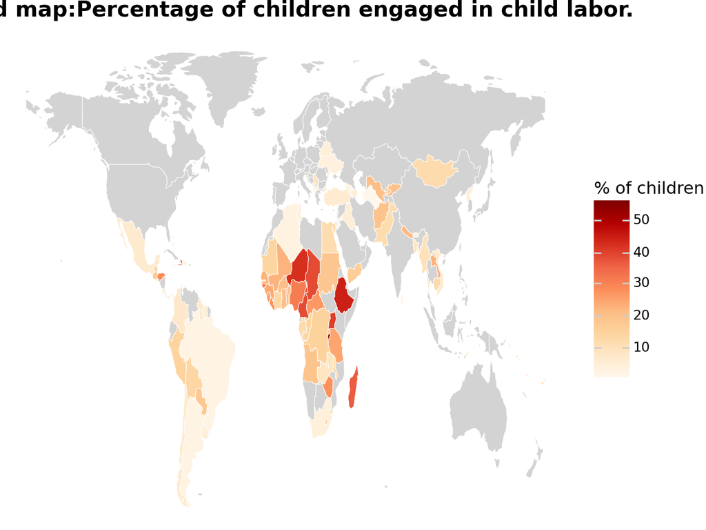

Figure 1: World map: Percentage of children (5-17 years old) engaged in child labor.

### **2. The most affected countries**

While the problem is global, it is unevenly distributed. In-depth analysis reveals that some countries have alarming rates. The following bar chart highlights the **10 countries** with the highest rates of child labor. These regions often require emergency interventions and increased international support.

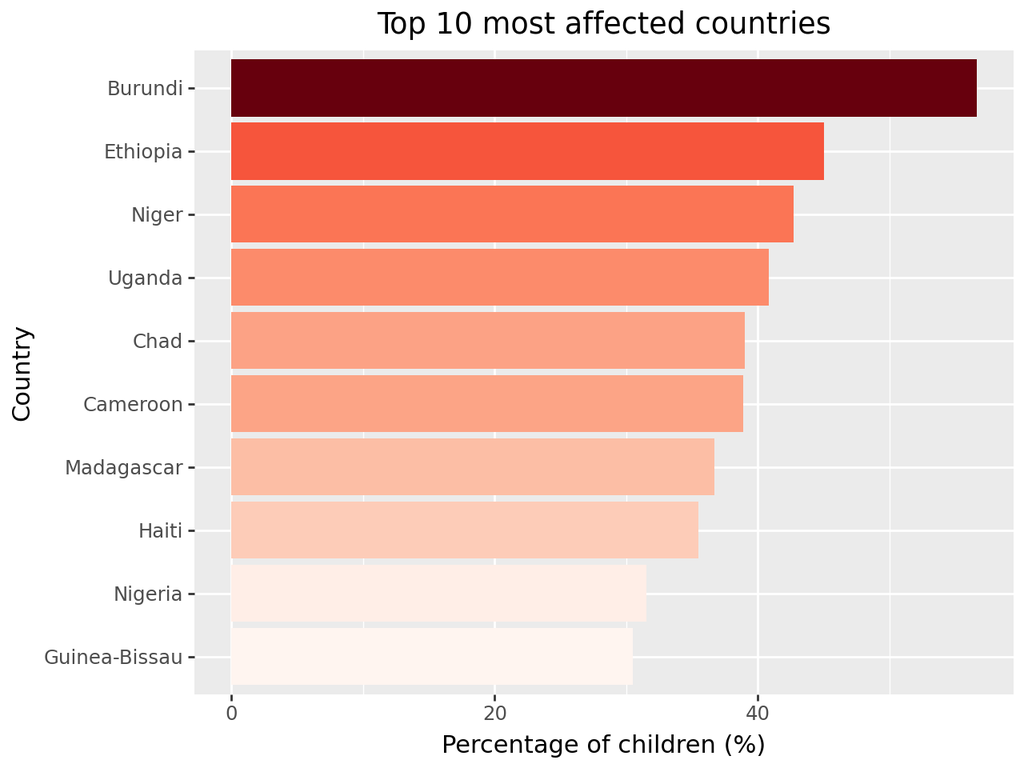

Figure 2: Top 10 des pays avec le taux le plus élevé de travail des enfants.

### **3. The weight of the economy: GDP vs. Child labor**

One of the fundamental questions is whether a nation’s poverty determines its rate of child labor. Cross-referencing the child labor indicator with **GDP per capita** reveals an interesting correlation. Generally, countries with lower GDP per capita tend to have a higher proportion of child labor, as shown in the regression line below.

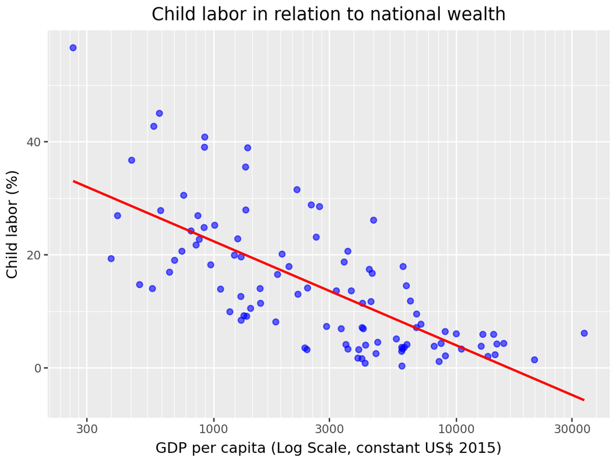

Figure 3: Relation entre le PIB par habitant et le taux de travail des enfants.

Child labor and economic hardship often have repercussions on the long-term health of populations. If we look at life expectancy over time globally, we can see a steady overall improvement. This timeline illustrates the evolution of average global life expectancy over the past few decades.

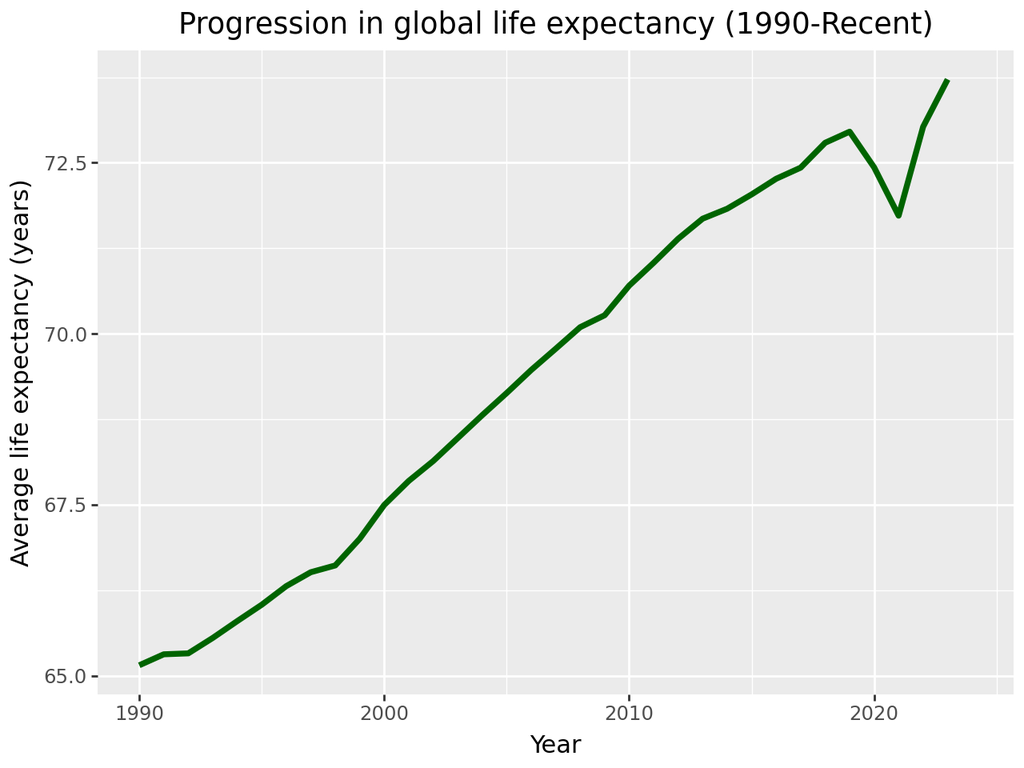

Figure 4: Évolution mondiale de l’espérance de vie moyenne au fil du temps.

### **Conclusion**

The data is clear, ending child labour requires more than just laws; it demands a global commitment to economic stability and universal education. By bridging the financial gap for vulnerable families and focusing on high-risk demographic zones, we can return this 160 million children to the classrooms.